# SOL-analysis

Kyle MacDonald

June 9, 2015

# Data processing, plotting, and analysis script for SOL PEEK data

```r
rm(list=ls())
```

## Read in data

```
## [1] "loading library"
```

### Demographics table

```r
sol_demo <- read.csv("../../raw_data/sol_demo_all.csv", stringsAsFactors = F)
sol_demo$Sub.Num <- as.character(sol_demo$Sub.Num)
```

### Eye movement data

```r
iChart <- read.csv("processed_data/sol-ichart-merged.csv",
                   check.names=F, stringsAsFactors=F)

iChart$Sub.Num <- as.character(iChart$Sub.Num)
```

## Filter dataset

Filter out participants that should not go into analyses based on exclusionary criteria: a) age, b) didn’t know signs in the task, c) not enough ASL exposure.

```r
exclude <- sol_demo %>%
    filter(include == "no") %>%
    select(Sub.Num, reason_excluded, stimuli, age_peek_months)

include <- sol_demo %>%
    filter(include == "yes") %>%
    select(Sub.Num, include,
           reason_excluded, stimuli,
           age_code, signs_produced)

iChart <- left_join(iChart, include, by = c("Sub.Num", "stimuli"))

iChart <- filter(iChart, include == "yes")
```

## Filter unknown signs

Create a clean target image variable.

```r
targets <- c("juice", "cookie", "cup", "ball", "shoe", "kitty",
             "doll", "teddy", "book", "birdy", "car", "sock")

make_clean_target <- function (target_image, targets) {
    target_img_clean <- targets[str_detect(target_image, targets)]
    return(target_img_clean)
}

iChart$clean_target_img <- unlist(sapply(iChart$Target.Image,
                                  function (x) make_clean_target(x, targets)))
```

Add unknown signs variable. Taken from sol_demo data frame.

```r
ss_unknown_signs <- sol_demo %>%
    filter(include == "yes") %>%
    select(Sub.Num, parent_report_unknown_signs)

iChart <- left_join(iChart, ss_unknown_signs, by = "Sub.Num")
```

Now we can filter the iChart, removing the “unknown” signs.

```r
ss_trials_df <- iChart %>%
    group_by(Sub.Num, parent_report_unknown_signs) %>%
    summarise(Trials = n())

# flag unknown trials
ss_unknown <- iChart %>%
    rowwise() %>%
    mutate(unknown_trial = ifelse(clean_target_img %in% parent_report_unknown_signs,
                                  "unknown_sign", "known_sign")) %>%
    select(Sub.Num, Tr.Num, unknown_trial)

# join this info with the original iChart
iChart$unknown_trial <- ss_unknown$unknown_trial

# now filter
iChart <- filter(iChart, unknown_trial == "known_sign")

# check to make sure our filtering worked correctly
post_filter_n <- iChart %>%
    group_by(Sub.Num) %>%
    summarise(Trials = n()) %>%
    select(Trials)

ss_trials_df$post_filter <- post_filter_n$Trials

ss_trials_df <- ss_trials_df %>%
    mutate(trials_removed = as.integer(Trials) - as.integer(post_filter))
```

```r
sum(ss_trials_df$trials_removed)
```

```
## [1] 22
```

## Remove prescreened out trials

```r
ss_prescreened <- iChart %>%
    group_by(Sub.Num) %>%
    filter(Prescreen.Notes != "") %>%
    summarise(num_prescreened = n())

ss_trials_df <- left_join(ss_trials_df, ss_prescreened, by = "Sub.Num")

ss_trials_df <- ss_trials_df %>%
    mutate(good_trials = Trials - sum(trials_removed, num_prescreened, na.rm=T))

iChart <- filter(iChart, Prescreen.Notes == "")
```

## Remove participants for having too few trials

We define too few trials as less than or equal to 25% of the total number of trials in the task.

```r
total_trials <- 32
trials_cut_point <- total_trials * .25

trials_filter <- ss_trials_df %>%
    mutate(exclude_few_trials = ifelse(good_trials <= trials_cut_point,
                                       "exclude", "include")) %>%
    select(Sub.Num, good_trials, exclude_few_trials)

# get the number of participants removed by filter
trials_filter %>% group_by(exclude_few_trials) %>% summarise(n())
```

```
## Source: local data frame [2 x 2]
##
##   exclude_few_trials n()
## 1            exclude   5
## 2            include  45
```

```r
# merge filtering information with iChart
iChart <- left_join(iChart, trials_filter, by = "Sub.Num")

# now filter
iChart <- filter(iChart, exclude_few_trials == "include")
```

## Get median split by age

```r
kids_age_descriptives <- iChart %>%
    filter(age_code == "child") %>%
    select(Sub.Num, Months) %>%
    distinct() %>%
    summarise(median(Months),
              max(Months),
              min(Months),
              sd(Months),
              n()) %>%
    print()
```

```
##   median(Months) max(Months) min(Months) sd(Months) n()
## 1             27          53          16   9.140259  29
```

```r
# add median split variable to iChart
iChart$age_group <- ifelse(iChart$Months < kids_age_descriptives$`median(Months)`,
                           "< 26.5 Months",
                           ifelse(iChart$Months >= kids_age_descriptives$`median(Months)` &
                                      iChart$Months <= kids_age_descriptives$`max(Months)`,
                                  "> 26.5 Months",
                                  "Adults"))
```

```r
gender_df <- iChart %>%
    filter(age_code == "child") %>%
    distinct(Sub.Num) %>%
    group_by(Sex, age_group) %>%
    summarise(count = unique(n())) %>%
    print()
```

```
## Source: local data frame [4 x 3]
## Groups: Sex
##
##   Sex     age_group count
## 1   F < 26.5 Months     8
## 2   F > 26.5 Months     9
## 3   M < 26.5 Months     6
## 4   M > 26.5 Months     6
```

```r
iChart %>% group_by(age_group) %>%
    summarise(n_distinct(Sub.Num),
              mean(Months),
              min(Months),
              max(Months))
```

```
## Source: local data frame [3 x 5]
##
##       age_group n_distinct(Sub.Num) mean(Months) min(Months) max(Months)
## 1 < 26.5 Months                  14     20.71308          16          26
## 2 > 26.5 Months                  15     36.18715          27          53
## 3        Adults                  16    430.57634         246         695
```

## Process iChart

First, we need to process the data, keeping only those trials on which the child was looking at the signer at F0.

- C: Center
- D: Distractor
- T: Target
- A: Away

includeOffCenter == FALSE -> only include trials child was looking at center at F0

includeOffCenter == TRUE -> include trials child was looking at center, target, or distractor at F0

```r
iChart %>% group_by("0", Response) %>% summarise(Trials = n())
```

```
## Source: local data frame [4 x 3]
## Groups: "0"
##
##   "0" Response Trials
## 1   0        A     28
## 2   0        C   1015
## 3   0        D     34
## 4   0        T     42
```

```r
# change all trials to "Vanilla"
iChart$Condition <- "Vanilla"

## define critical onset, change Cs to Ds and everything else to As
iChart <- defineOnsetSOL(iChart, critonset=0, end_critonset=300,
                         includeOffCenter=FALSE, includeWindow = FALSE)

iChart %>% group_by("0", Response) %>% summarise(Trials = n())
```

```
## Source: local data frame [2 x 3]
## Groups: "0"
##
##   "0" Response Trials
## 1   0        A    104
## 2   0        D   1015
```

## Flag C_T and C_D Trials

Datawiz does not tell us which shifts land on a target vs. a disctractor. So we need to use a function that flags each trial as one of the following:

- C_T: center to target
- C_D: center to distractor
- C-C: center to center (child leaves the signer, goes away, and comes back to signer)
- no_shift
- off_signer

```r
# apply it to each row in our datase
trial_types <- apply(iChart, 1, trial_type_fun)

# merge this information back with the iChart
iChart <- cbind(iChart, trial_types)
```

```r
iChart %>% group_by(trial_types) %>% summarise(Trials = n())
```

```
## Source: local data frame [4 x 2]
##
##   trial_types Trials
## 1         C_D    131
## 2         C_T    822
## 3    no_shift     62
## 4  off_signer    104
```

Next, we compute statistics over long window 0-5000 ms. This will allow us to see a distribution of RTs, which we will use to determine our analysis window.

```r
iChart <- computeStatistics(iChart, startWindow=0, endWindow=5000)
```

```
## [1] "### Trials left ###"
## [1] 1100
## [1] 1050
## [1] 1000
## [1] 950
## [1] 900
## [1] 850
## [1] 800
## [1] 750
## [1] 700
## [1] 650
## [1] 600
## [1] 550
## [1] 500
## [1] 450
## [1] 400
## [1] 350
## [1] 300
## [1] 250
## [1] 200
## [1] 150
## [1] 100
## [1] 50
## [1] 0
```

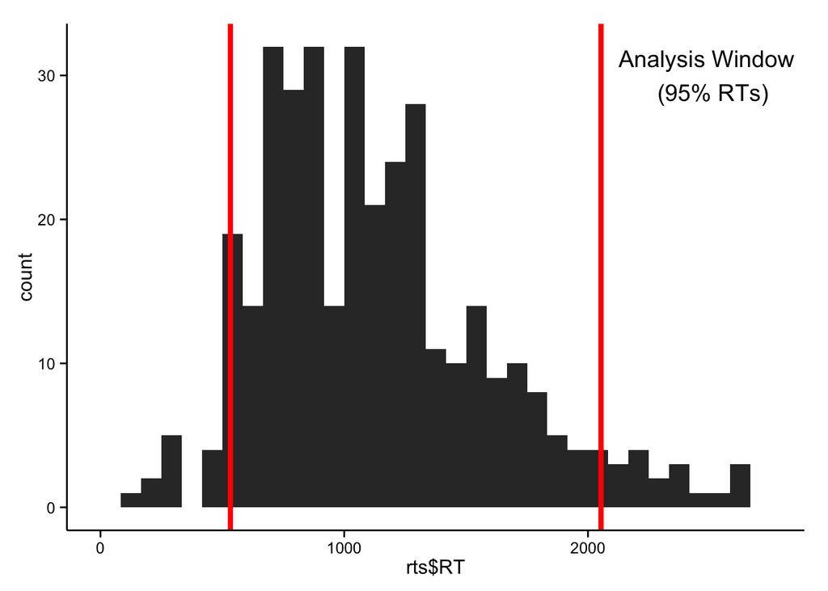

```r
# get analyisis window where 90% of RTs occur for kids, include all shifts
rts <- filter(iChart, trial_types %in% c("C_T"), age_group != "Adults")

analysis.window <- quantile(rts$RT, probs=c(0.05, 0.95), na.rm=T)

qplot(rts$RT) +
    geom_vline(x=analysis.window[1], col="red", lwd=1.5) +
    geom_vline(x=analysis.window[2], col="red", lwd=1.5) +
    annotate("text", x = 2500, y = 30,
              label = "Analysis Window \n (95% RTs)")
```

```r
iChart <- computeStatistics(iChart, startWindow=0, endWindow=2500)
```

```
## [1] "### Trials left ###"
## [1] 1100
## [1] 1050
## [1] 1000
## [1] 950
## [1] 900
## [1] 850
## [1] 800
## [1] 750
## [1] 700
## [1] 650
## [1] 600
## [1] 550
## [1] 500
## [1] 450
## [1] 400
## [1] 350
## [1] 300
## [1] 250
## [1] 200
## [1] 150
## [1] 100
## [1] 50
## [1] 0
```

Reject trials with really long RTs and with long gaps. Gaps are defined as a sequence of frames when the child is not looking at either picture or at the signer.

```r
iChart <- filteriChart(iChart, minRT = analysis.window[1], maxRT = analysis.window[2], maxfirstgap=15, maxlonggap=15)
```

## Get mean Accuracy and RT for each participant

```r
acc_ss <- poolData(meanAccuracy(iChart, startWindowAcc=500, endWindowAcc=2000),
                RejectFirstGap=TRUE,RejectLongestGap=TRUE,
                RejectRT=FALSE, color=TRUE, dependent="Accuracy",
                group="", facet="", dodge="",
                xlab="", ylab= "Proportion\n  Looking\n  to target",
                paired=TRUE, miny = 0.2, maxy = 0.80,
                size=13, legend.direction="horizontal",
                legend.position="bottom",
                breaks=c(0.25, 0.50, 0.75))

## Compute reaction time for each age group only on C_T trials
rt_ss <- poolData(filter(iChart, trial_types %in% c("C_T")),
               RejectFirstGap=TRUE, RejectLongestGap=TRUE,
               RejectRT=TRUE, color=FALSE, dependent="RT", group="",
               facet="", dodge="Response",
               xlab="", ylab="mean RT (ms)",
               paired=TRUE,
               miny = 400, maxy=1300,
               size=13,
               legend.direction = "horizontal",
               legend.position="bottom",
               breaks=c(400, 800, 1200))
```

## Get mean Acc and RT for each participant by condition

```r
acc <- poolData(meanAccuracy(iChart, startWindowAcc=500, endWindowAcc=2000),
                RejectFirstGap=TRUE,RejectLongestGap=TRUE,
                RejectRT=FALSE, color=TRUE, dependent="Accuracy",
                group="age_group", facet="", dodge="",
                xlab="", ylab= "Proportion\n  Looking\n  to target",
                paired=TRUE, miny = 0.2, maxy = 0.80,
                size=13, legend.direction="horizontal",
                legend.position="bottom",
                breaks=c(0.25, 0.50, 0.75))

## Compute reaction time for each age group only on C_T trials
rt <- poolData(filter(iChart, trial_types %in% c("C_T")),
               RejectFirstGap=TRUE, RejectLongestGap=TRUE,
               RejectRT=TRUE, color=FALSE, dependent="RT", group="age_group",
               facet="", dodge="Response",
               xlab="", ylab="mean RT (ms)",
               paired=TRUE,
               miny = 400, maxy=1300,
               size=13,
               legend.direction = "horizontal",
               legend.position="bottom",
               breaks=c(400, 800, 1200))
```

### Statistics

Get mean accuracy and rt for each participant

Some munging to get data frame for analysis. Variables needed for each subject:

- Mean acc
- Mean rt
- Signs produced
- Age
- Age condition

```r
# merge acc/rt van1
ss <- merge(acc_ss, rt_ss, by="Sub.Num")

# merge with demo info
ss <- merge(ss, filter(sol_demo, include=="yes"), by="Sub.Num")

# get age bins
ss_age_bins <- iChart %>%
    select(Sub.Num, age_group, Months) %>%
    distinct()

ss <- merge(ss, ss_age_bins, by="Sub.Num")

# clean up variable names in data frame
names(ss)[names(ss)=="Vanilla"] <- "mean_accuracy"
names(ss)[names(ss)=="Vanilla_D"] <- "mean_rt"
```

## First shifts

```r
ss_first_shifts <- iChart %>%
    filter(trial_types %in% c("C_T", "C_D")) %>%
    group_by(Sub.Num, trial_types, age_group) %>%
    summarise(count = n())

ss_first_shifts_prop <- ss_first_shifts %>%
    group_by(Sub.Num) %>%
    summarise(total_trials_shifting = sum(count)) %>%
    left_join(ss_first_shifts, by = "Sub.Num") %>%
    mutate(shift_prop = round(count / total_trials_shifting, 2))

# add to ss full data frame
ss <- ss_first_shifts %>%
    select(Sub.Num, count, trial_types) %>%
    spread(trial_types, count) %>%
    transmute(Sub.Num = Sub.Num, C_D_count = C_D, C_T_count = C_T) %>%
    left_join(ss, by = "Sub.Num")

# add to ss full data frame
ss <- ss_first_shifts_prop %>%
    select(Sub.Num, shift_prop, trial_types,
           total_trials_shifting) %>%
    spread(trial_types, shift_prop) %>%
    transmute(Sub.Num = Sub.Num, C_D_prop = C_D, C_T_prop = C_T) %>%
    left_join(ss, by = "Sub.Num")

# flag chance first shifters -- need to find a principled way to do this
ss <- ss %>%
    mutate(C_D_prop = ifelse(C_T_prop == 1, 0, C_D_prop),
           exclude_chance_shifter = ifelse(Sub.Num %in% c("30050", "30018", "30051", "30086", "30088"), "exclude", "include"))
```

Set up filter to just include kids for correlation analyses.

```r
ss_kids <- filter(ss, age_group != "Adults")
ss_rt <- filter(ss, age_group != "Adults", exclude_chance_shifter == "include")
```

```r
write.csv(ss_kids, "../bayesian-data-analysis/sol_ss_kids.csv", row.names = F)
```

## Look at all correlations

```r
Hmisc::rcorr(as.matrix(select(ss_kids, mean_accuracy, C_T_prop, mean_rt, signs_produced, Months)))
```

```
##                mean_accuracy C_T_prop mean_rt signs_produced Months
## mean_accuracy           1.00     0.55   -0.53           0.46   0.64
## C_T_prop                0.55     1.00   -0.12           0.32   0.35
## mean_rt                -0.53    -0.12    1.00          -0.49  -0.34
## signs_produced          0.46     0.32   -0.49           1.00   0.76
## Months                  0.64     0.35   -0.34           0.76   1.00
##
## n
##                mean_accuracy C_T_prop mean_rt signs_produced Months
## mean_accuracy             29       29      29             28     29
## C_T_prop                  29       29      29             28     29
## mean_rt                   29       29      29             28     29
## signs_produced            28       28      28             28     28
## Months                    29       29      29             28     29
##
## P
##                mean_accuracy C_T_prop mean_rt signs_produced Months
## mean_accuracy                0.0020   0.0030  0.0142         0.0002
## C_T_prop       0.0020                 0.5351  0.0964         0.0628
## mean_rt        0.0030        0.5351           0.0079         0.0747
## signs_produced 0.0142        0.0964   0.0079                 0.0000
## Months         0.0002        0.0628   0.0747  0.0000
```

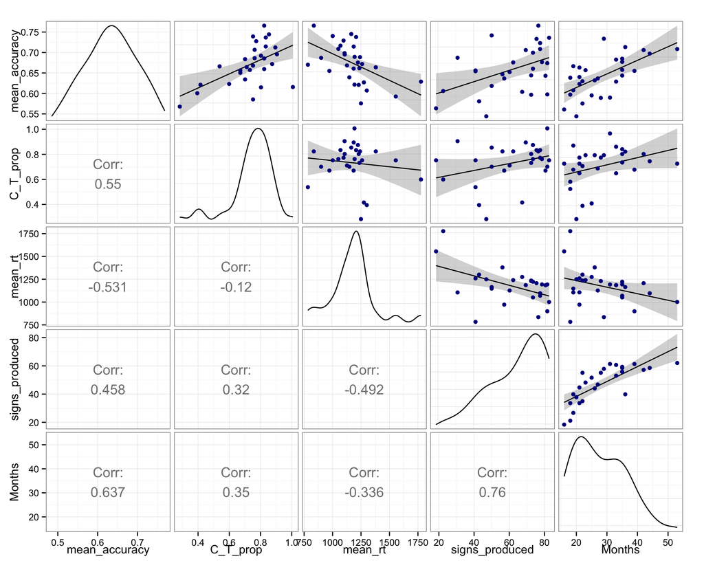

```r
ggpairs(data = select(ss_kids, mean_accuracy, C_T_prop, mean_rt, signs_produced, Months),
        upper = list(continuous = "smooth", combo = "cor",
                     params = c(method = "lm", color="darkblue")),
        lower = list(continuous = "cor"),
        diag = list(continuous = "density")) +
    theme_bw()
```

Just RT.

```r
Hmisc::rcorr(as.matrix(select(ss_rt, mean_rt, signs_produced, Months)))
```

```
##                mean_rt signs_produced Months
## mean_rt           1.00          -0.51  -0.38
## signs_produced   -0.51           1.00   0.72
## Months           -0.38           0.72   1.00
##
## n
##                mean_rt signs_produced Months
## mean_rt             24             23     24
## signs_produced      23             23     23
## Months              24             23     24
##
## P
##                mean_rt signs_produced Months
## mean_rt                0.0132         0.0663
## signs_produced 0.0132                 0.0001
## Months         0.0663  0.0001
```

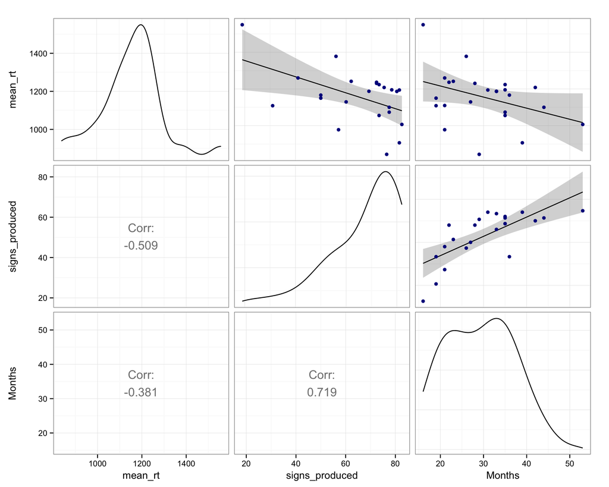

```r
ggpairs(data = select(ss_rt, mean_rt, signs_produced, Months),
        upper = list(continuous = "smooth", combo = "cor",
                     params = c(method = "lm", color="darkblue")),
        lower = list(continuous = "cor"),
        diag = list(continuous = "density")) +
    theme_bw()
```

## Test difference in Acc/RT between age groups

```r
t.test(mean_accuracy ~ age_group, data=ss_kids)
```

```
##
##  Welch Two Sample t-test
##
## data:  mean_accuracy by age_group
## t = -3.3317, df = 26.887, p-value = 0.00252
## alternative hypothesis: true difference in means is not equal to 0
## 95 percent confidence interval:
##  -0.11969437 -0.02844552
## sample estimates:
## mean in group < 26.5 Months mean in group > 26.5 Months
##                   0.5935824                   0.6676523
```

```r
t.test(mean_rt ~ age_group, data=ss_kids)
```

```
##
##  Welch Two Sample t-test
##
## data:  mean_rt by age_group
## t = 1.8546, df = 18.91, p-value = 0.07931
## alternative hypothesis: true difference in means is not equal to 0
## 95 percent confidence interval:
##  -16.59593 274.07901
## sample estimates:
## mean in group < 26.5 Months mean in group > 26.5 Months
##                    1242.685                    1113.943
```

# Plot individual participants performance

```r
createPlots(iChart, startWindow=0, endWindow=2000, RejectLongestGap=FALSE,
            RejectFirstGap=FALSE, RejectRT=FALSE, color=TRUE, smooth=400,
            targetEnd=800, carrier="", targets=c(""),
            group="age_group",  plotStats="PP", miny = 0.4, maxy=0.95, size=15,
            legend.direction = "vertical", legend.position=c(0.85, 0.9),
            breaks=c(0.25, 0.50, 0.75), x.target=0.33)
```

```r
ss.et <- read.table("sol-ichart-v1-processed_PP_graphValues_by_subs_0_2000_minRT_33_maxRT_2433_lg_59_fg_34_n_45.txt", header = T)
ss.et$Sub.Num <- as.character(ss.et$Sub.Num)
```

### Some munging to format data for plotting

```r
detach("package:reshape", unload=TRUE)

#strip X from header
names(ss.et) <- gsub("X", "", names(ss.et))

ss.et <- left_join(ss.et, ss_kids, by="Sub.Num")

#melt to long form for plotting
ss.et.long <- reshape2::melt(ss.et,
                   id.vars=c("Sub.Num", "Condition",
                             "Months", "signs_produced",
                             "groupping", "stimuli"),
                   variable.name = "Time.ms",
                   value.name = "accuracy")

#convert sub.num to a factor
ss.et.long <- ss.et.long %>%
    mutate(Sub.Num = as.factor(Sub.Num),
           Time.ms = as.numeric(as.character(Time.ms)),
           Months = as.factor(Months),
           accuracy = as.numeric(accuracy))
```

### Exploratory Plots

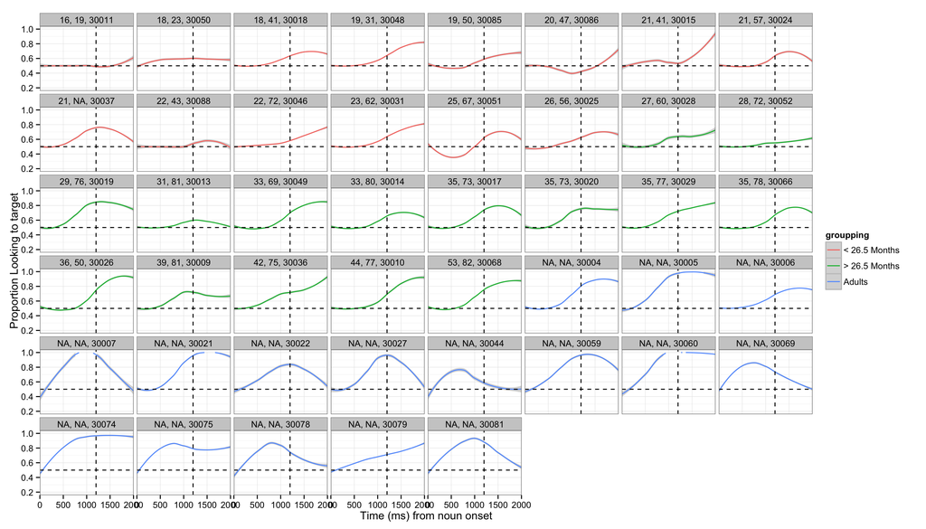

```r
# set breaks for x-axis
breaks <- seq(0,2000, by=500)

qplot(data = ss.et.long, x = Time.ms, y = accuracy,
      color=groupping, geom="smooth", method = "loess",
      ylim=c(0.2,1), xlab=c("Time (ms) from noun onset"),
      ylab=c("Proportion Looking to target")) +
    geom_hline(yintercept = 0.5, linetype="dashed") +
    scale_x_discrete(breaks = breaks) +
    facet_wrap(Months+signs_produced~Sub.Num, ncol=8) +
    #guides(color=FALSE) +
    geom_vline(xintercept=1200, linetype = "dashed") +
    theme(axis.text.x = element_text(angle = 75, hjust = 1)) +
    theme_bw()
```

### Get confidence interval for graph values

```r
ms_graph_values <- ss.et.long %>%
    group_by(groupping, Time.ms) %>%
    summarise(mean_accuracy = mean(accuracy),
              ci.high = ci.high(accuracy),
              ci.low = ci.low(accuracy))
```

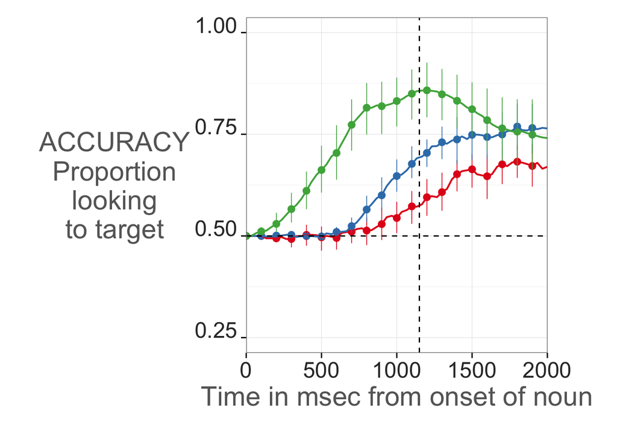

```r
breaks <- seq(0,2000, by=500)
y_breaks <- seq(0.25,1.0, by = 0.25)
points <- seq(0,1900, by = 100)

qplot(data = ms_graph_values, x = Time.ms, y = mean_accuracy,
      color=groupping, geom = "blank", xlab=c("Time in msec from onset of noun"),
      ylab=c("ACCURACY\nProportion\nlooking\nto target")) +
    geom_point(data = filter(ms_graph_values, Time.ms %in% points), size=3) +
    geom_line(size=0.7) +
    geom_linerange(data = filter(ms_graph_values, Time.ms %in% points),
                   aes(ymin=mean_accuracy - ci.low,
                       ymax=mean_accuracy + ci.high),
                   width = .03, size=0.3, alpha = 1) +
    scale_color_brewer(type = "qual", palette = "Set1") +
    scale_x_discrete(breaks = breaks) +
    scale_y_continuous(limits=c(0.25, 1.0), breaks = y_breaks) +
    geom_hline(yintercept = 0.5, linetype="dashed") +
    geom_vline(xintercept=1150, linetype = "dashed") +
    guides(color=F) +
    theme_bw() +
    theme(axis.title.x = element_text(colour="grey40",size=22,
                                      angle=0,hjust=0.5,vjust=0,face="plain"),
          axis.title.y = element_text(colour="grey40",size=22,
                                      angle=0,hjust=0.5,vjust=0.5,face="plain"),
          axis.text.x = element_text(colour="grey20",size=18,
                                     angle=0,hjust=0.5,vjust=0,face="plain"),
          axis.text.y = element_text(colour="grey20",size=18,
                                     angle=0,hjust=0.5,vjust=0,face="plain"),
         plot.margin = unit(c(0.5,2,1,1), "cm"))
```